# Midterm exam

## 1101

讀取1101的資料。

```r
library(xts)
data1<-new.env()
data1$prices<-tw20.all.1$'1101'
prices<-data1$prices
sma1101<-SMA(prices, 90)
head(sma1101, 91)
```

```
##                 SMA
## 2014-01-02       NA
## 2014-01-03       NA
## 2014-01-06       NA
## 2014-01-07       NA
## 2014-01-08       NA
## 2014-01-09       NA
## 2014-01-10       NA
## 2014-01-13       NA
## 2014-01-14       NA
## 2014-01-15       NA
## 2014-01-16       NA
## 2014-01-17       NA
## 2014-01-20       NA
## 2014-01-21       NA
## 2014-01-22       NA
## 2014-01-23       NA
## 2014-01-24       NA
## 2014-01-27       NA
## 2014-02-05       NA
## 2014-02-06       NA
## 2014-02-07       NA
## 2014-02-10       NA
## 2014-02-11       NA
## 2014-02-12       NA
## 2014-02-13       NA
## 2014-02-14       NA
## 2014-02-17       NA
## 2014-02-18       NA
## 2014-02-19       NA
## 2014-02-20       NA
## 2014-02-21       NA
## 2014-02-24       NA
## 2014-02-25       NA
## 2014-02-26       NA
## 2014-02-27       NA
## 2014-03-03       NA
## 2014-03-04       NA
## 2014-03-05       NA
## 2014-03-06       NA
```

[output cut: 37 more lines]

```
## 2014-04-30       NA
## 2014-05-02       NA
## 2014-05-05       NA
## 2014-05-06       NA
## 2014-05-07       NA
## 2014-05-08       NA
## 2014-05-09       NA
## 2014-05-12       NA
## 2014-05-13       NA
## 2014-05-14       NA
## 2014-05-15       NA
## 2014-05-16       NA
## 2014-05-19       NA
## 2014-05-20 33.37589
## 2014-05-21 33.36467
```

分別看日期、價錢。

```r
bt.prep(data1, align='keep.all')
names(data1)
```

```
## [1] "prices"          "dates"           "weight"          "symbolnames"
## [5] "execution.price"
```

```r
data1$dates
```

```
##    [1] "2014-01-02" "2014-01-03" "2014-01-06" "2014-01-07" "2014-01-08"
##    [6] "2014-01-09" "2014-01-10" "2014-01-13" "2014-01-14" "2014-01-15"
##   [11] "2014-01-16" "2014-01-17" "2014-01-20" "2014-01-21" "2014-01-22"
##   [16] "2014-01-23" "2014-01-24" "2014-01-27" "2014-02-05" "2014-02-06"
##   [21] "2014-02-07" "2014-02-10" "2014-02-11" "2014-02-12" "2014-02-13"
##   [26] "2014-02-14" "2014-02-17" "2014-02-18" "2014-02-19" "2014-02-20"
##   [31] "2014-02-21" "2014-02-24" "2014-02-25" "2014-02-26" "2014-02-27"
##   [36] "2014-03-03" "2014-03-04" "2014-03-05" "2014-03-06" "2014-03-07"
##   [41] "2014-03-10" "2014-03-11" "2014-03-12" "2014-03-13" "2014-03-14"
##   [46] "2014-03-17" "2014-03-18" "2014-03-19" "2014-03-20" "2014-03-21"
##   [51] "2014-03-24" "2014-03-25" "2014-03-26" "2014-03-27" "2014-03-28"
##   [56] "2014-03-31" "2014-04-01" "2014-04-02" "2014-04-03" "2014-04-07"
##   [61] "2014-04-08" "2014-04-09" "2014-04-10" "2014-04-11" "2014-04-14"
##   [66] "2014-04-15" "2014-04-16" "2014-04-17" "2014-04-18" "2014-04-21"
##   [71] "2014-04-22" "2014-04-23" "2014-04-24" "2014-04-25" "2014-04-28"
```

[output cut: 231 more lines]

```r
data1$prices
```

```
##            prices
## 2014-01-02     NA
## 2014-01-03     NA
## 2014-01-06     NA
## 2014-01-07     NA
## 2014-01-08     NA
## 2014-01-09     NA
## 2014-01-10     NA
## 2014-01-13     NA
## 2014-01-14     NA
## 2014-01-15     NA
## 2014-01-16     NA
## 2014-01-17     NA
## 2014-01-20     NA
## 2014-01-21     NA
## 2014-01-22     NA
## 2014-01-23     NA
## 2014-01-24     NA
## 2014-01-27     NA
## 2014-02-05     NA
## 2014-02-06     NA
## 2014-02-07     NA
## 2014-02-10     NA
## 2014-02-11     NA
## 2014-02-12     NA
## 2014-02-13     NA
## 2014-02-14     NA
## 2014-02-17     NA
## 2014-02-18     NA
## 2014-02-19     NA
## 2014-02-20     NA
## 2014-02-21     NA
## 2014-02-24     NA
## 2014-02-25     NA
## 2014-02-26     NA
## 2014-02-27     NA
## 2014-03-03     NA
## 2014-03-04     NA
## 2014-03-05     NA
## 2014-03-06     NA
```

[output cut: 1175 more lines]

```
## 2018-12-11     NA
## 2018-12-12     NA
## 2018-12-13     NA
## 2018-12-14     NA
## 2018-12-17     NA
## 2018-12-18     NA
## 2018-12-19     NA
## 2018-12-20     NA
## 2018-12-21     NA
## 2018-12-22     NA
## 2018-12-24     NA
## 2018-12-25     NA
## 2018-12-26     NA
## 2018-12-27     NA
## 2018-12-28     NA
```

```r
data1$prices<-prices

class(data1$dates)
```

```
## [1] "Date"
```

```r
data1$execution.price = prices
data1$weight[] = 1
buy.hold.1101 <- bt.run.share(data1, clean.signal=F, trade.summary = TRUE)
```

```
## Latest weights :
##            prices
## 2018-12-28    100
##
## Performance summary :
##  CAGR    Best    Worst
##  1.7 6.9 -8.1
```

```r
buy.hold.1101 <-bt.run(data1)
```

```
## Latest weights :
##            prices
## 2018-12-28    100
##
## Performance summary :
##  CAGR    Best    Worst
##  1.7 6.9 -8.1
```

讀取sma 90天的資料。

```r
sma1101<-SMA(prices, 90)
head(sma1101, 91)
```

```
##                 SMA
## 2014-01-02       NA
## 2014-01-03       NA
## 2014-01-06       NA
## 2014-01-07       NA
## 2014-01-08       NA
## 2014-01-09       NA
## 2014-01-10       NA
## 2014-01-13       NA
## 2014-01-14       NA
## 2014-01-15       NA
## 2014-01-16       NA
## 2014-01-17       NA
## 2014-01-20       NA
## 2014-01-21       NA
## 2014-01-22       NA
## 2014-01-23       NA
## 2014-01-24       NA
## 2014-01-27       NA
## 2014-02-05       NA
## 2014-02-06       NA
## 2014-02-07       NA
## 2014-02-10       NA
## 2014-02-11       NA
## 2014-02-12       NA
## 2014-02-13       NA
## 2014-02-14       NA
## 2014-02-17       NA
## 2014-02-18       NA
## 2014-02-19       NA
## 2014-02-20       NA
## 2014-02-21       NA
## 2014-02-24       NA
## 2014-02-25       NA
## 2014-02-26       NA
## 2014-02-27       NA
## 2014-03-03       NA
## 2014-03-04       NA
## 2014-03-05       NA
## 2014-03-06       NA
```

[output cut: 37 more lines]

```
## 2014-04-30       NA
## 2014-05-02       NA
## 2014-05-05       NA
## 2014-05-06       NA
## 2014-05-07       NA
## 2014-05-08       NA
## 2014-05-09       NA
## 2014-05-12       NA
## 2014-05-13       NA
## 2014-05-14       NA
## 2014-05-15       NA
## 2014-05-16       NA
## 2014-05-19       NA
## 2014-05-20 33.37589
## 2014-05-21 33.36467
```

```r
data1$weight[] <- iif(prices >= sma1101, 1, 0)
sma90.1101 <- bt.run(data1, trade.summary=T)
```

```
## Latest weights :
##            prices
## 2018-12-28      0
##
## Performance summary :
##  CAGR    Best    Worst
##  0.6 6.7 -8.1
```

```r
data1$weight[] <- iif(prices >= sma1101, 1, -1)
sma90.1101.short <- bt.run(data1, trade.summary=T)
```

```
## Latest weights :
##            prices
## 2018-12-28   -100
##
## Performance summary :
##  CAGR    Best    Worst
##  -2.9    6.7 -8.1
```

```r
models<-list("SMA1101"= sma90.1101,
             "SMA1101_short" = sma90.1101.short,
             "BH 1101" = buy.hold.1101)
```

# 第一、二張圖：

黑色線為SMA1101 1.03，紅色線為SMA1101_short 0.86，綠色線為BH 1101 1.09。並顯示出表格。

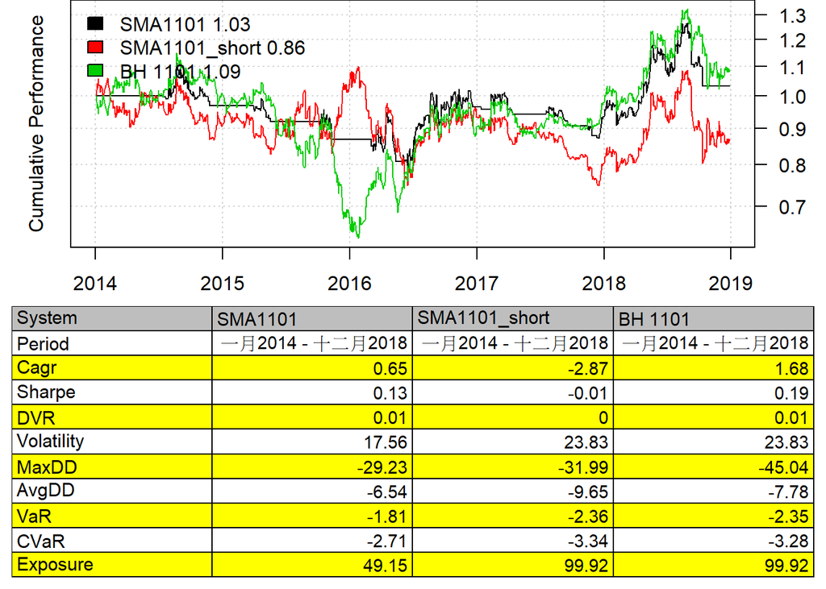

```r
strategy.performance.snapshoot(models, T)
```

# 第三張圖：

顯示出Sharpe、DVR、Cagr、MaxDD四個的長條圖。

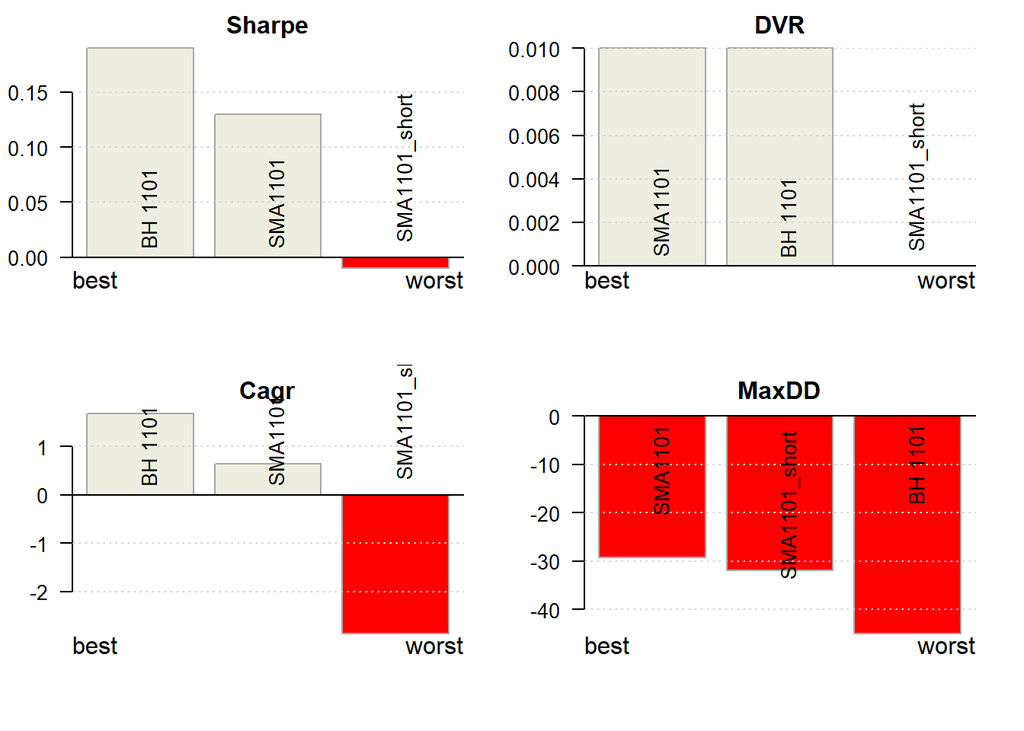

```r
strategy.performance.snapshoot(models, control=list(comparison=T), sort.performance=T)
```

# 第四張圖：

顯示為表格。

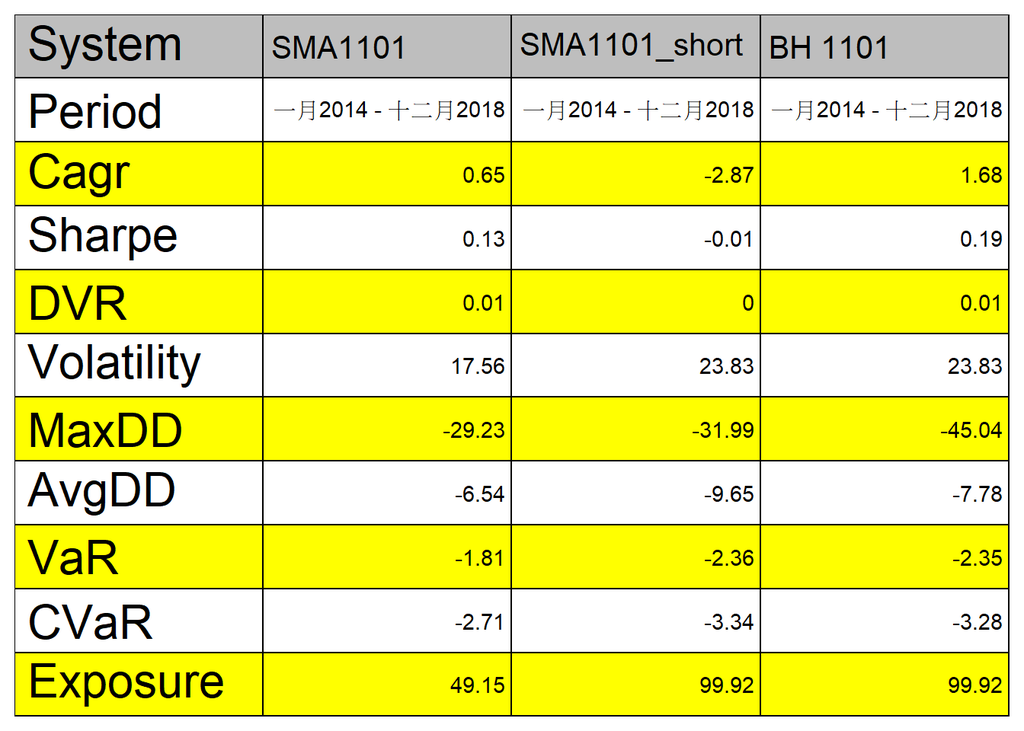

```
##            SMA1101                 SMA1101_short
## Period     "一月2014 - 十二月2018" "一月2014 - 十二月2018"
## Cagr       "0.65"                  "-2.87"
## Sharpe     "0.13"                  "-0.01"
## DVR        "0.01"                  "0"
## Volatility "17.56"                 "23.83"
## MaxDD      "-29.23"                "-31.99"
## AvgDD      "-6.54"                 "-9.65"
## VaR        "-1.81"                 "-2.36"
## CVaR       "-2.71"                 "-3.34"
## Exposure   "49.15"                 "99.92"
##            BH 1101
## Period     "一月2014 - 十二月2018"
## Cagr       "1.68"
## Sharpe     "0.19"
## DVR        "0.01"
## Volatility "23.83"
## MaxDD      "-45.04"
## AvgDD      "-7.78"
## VaR        "-2.35"
## CVaR       "-3.28"
## Exposure   "99.92"
```

```r
plotbt.strategy.sidebyside(models, return.table=T)
```

```r
library(ggplot2)
all.1101<-merge.xts(sma90.1101$equity,
                    sma90.1101.short$equity,
                    buy.hold.1101$equity)
colnames(all.1101)<-c("sma1101", "sma1101 short", "BH")
head(all.1101)
```

```
##            sma1101 sma1101 short        BH
## 2014-01-02       1      1.000000 1.0000000
## 2014-01-03       1      1.018620 0.9813797
## 2014-01-06       1      1.040482 0.9603175
## 2014-01-07       1      1.027253 0.9725275
## 2014-01-08       1      1.033056 0.9670330
## 2014-01-09       1      1.056535 0.9450549
```

```r
all.1101.long<-fortify(all.1101, melt=T)
head(all.1101.long)
```

```
##        Index  Series Value
## 1 2014-01-02 sma1101     1
## 2 2014-01-03 sma1101     1
## 3 2014-01-06 sma1101     1
## 4 2014-01-07 sma1101     1
## 5 2014-01-08 sma1101     1
## 6 2014-01-09 sma1101     1
```

圖的標題為Cumulative returns of 1101s。

X軸為year，Y軸為cumulative returns。

粉紅色線為sma1101，綠色線為sma1101 short，藍色線為BH。

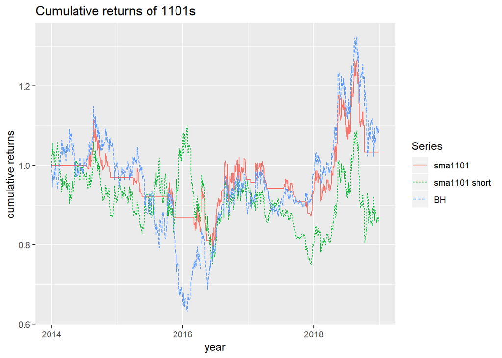

```r
title = "Cumulative returns of 1101s"
p = ggplot(all.1101.long, aes(x = Index, y = Value)) +
  geom_line(aes(linetype = Series, color = Series)) +
  #geom_point(aes(shape = Series))+
  xlab("year") + ylab("cumulative returns")+
  ggtitle(title)
p
```

## 1216

讀取1216的資料。

```r
library(xts)
data1<-new.env()
data1$prices<-tw20.all.1$'1216'
prices<-data1$prices
sma1216<-SMA(prices, 90)
head(sma1216, 91)
```

```
##                 SMA
## 2014-01-02       NA
## 2014-01-03       NA
## 2014-01-06       NA
## 2014-01-07       NA
## 2014-01-08       NA
## 2014-01-09       NA
## 2014-01-10       NA
## 2014-01-13       NA
## 2014-01-14       NA
## 2014-01-15       NA
## 2014-01-16       NA
## 2014-01-17       NA
## 2014-01-20       NA
## 2014-01-21       NA
## 2014-01-22       NA
## 2014-01-23       NA
## 2014-01-24       NA
## 2014-01-27       NA
## 2014-02-05       NA
## 2014-02-06       NA
## 2014-02-07       NA
## 2014-02-10       NA
## 2014-02-11       NA
## 2014-02-12       NA
## 2014-02-13       NA
## 2014-02-14       NA
## 2014-02-17       NA
## 2014-02-18       NA
## 2014-02-19       NA
## 2014-02-20       NA
## 2014-02-21       NA
## 2014-02-24       NA
## 2014-02-25       NA
## 2014-02-26       NA
## 2014-02-27       NA
## 2014-03-03       NA
## 2014-03-04       NA
## 2014-03-05       NA
## 2014-03-06       NA
```

[output cut: 37 more lines]

```
## 2014-04-30       NA
## 2014-05-02       NA
## 2014-05-05       NA
## 2014-05-06       NA
## 2014-05-07       NA
## 2014-05-08       NA
## 2014-05-09       NA
## 2014-05-12       NA
## 2014-05-13       NA
## 2014-05-14       NA
## 2014-05-15       NA
## 2014-05-16       NA
## 2014-05-19       NA
## 2014-05-20 38.13300
## 2014-05-21 38.11222
```

分別看日期、價錢。

```r
bt.prep(data1, align='keep.all')
names(data1)
```

```
## [1] "prices"          "dates"           "weight"          "symbolnames"
## [5] "execution.price"
```

```r
data1$dates
```

```
##    [1] "2014-01-02" "2014-01-03" "2014-01-06" "2014-01-07" "2014-01-08"
##    [6] "2014-01-09" "2014-01-10" "2014-01-13" "2014-01-14" "2014-01-15"
##   [11] "2014-01-16" "2014-01-17" "2014-01-20" "2014-01-21" "2014-01-22"
##   [16] "2014-01-23" "2014-01-24" "2014-01-27" "2014-02-05" "2014-02-06"
##   [21] "2014-02-07" "2014-02-10" "2014-02-11" "2014-02-12" "2014-02-13"
##   [26] "2014-02-14" "2014-02-17" "2014-02-18" "2014-02-19" "2014-02-20"
##   [31] "2014-02-21" "2014-02-24" "2014-02-25" "2014-02-26" "2014-02-27"
##   [36] "2014-03-03" "2014-03-04" "2014-03-05" "2014-03-06" "2014-03-07"
##   [41] "2014-03-10" "2014-03-11" "2014-03-12" "2014-03-13" "2014-03-14"
##   [46] "2014-03-17" "2014-03-18" "2014-03-19" "2014-03-20" "2014-03-21"
##   [51] "2014-03-24" "2014-03-25" "2014-03-26" "2014-03-27" "2014-03-28"
##   [56] "2014-03-31" "2014-04-01" "2014-04-02" "2014-04-03" "2014-04-07"
##   [61] "2014-04-08" "2014-04-09" "2014-04-10" "2014-04-11" "2014-04-14"
##   [66] "2014-04-15" "2014-04-16" "2014-04-17" "2014-04-18" "2014-04-21"
##   [71] "2014-04-22" "2014-04-23" "2014-04-24" "2014-04-25" "2014-04-28"
```

[output cut: 231 more lines]

```r
data1$prices
```

```
##            prices
## 2014-01-02     NA
## 2014-01-03     NA
## 2014-01-06     NA
## 2014-01-07     NA
## 2014-01-08     NA
## 2014-01-09     NA
## 2014-01-10     NA
## 2014-01-13     NA
## 2014-01-14     NA
## 2014-01-15     NA
## 2014-01-16     NA
## 2014-01-17     NA
## 2014-01-20     NA
## 2014-01-21     NA
## 2014-01-22     NA
## 2014-01-23     NA
## 2014-01-24     NA
## 2014-01-27     NA
## 2014-02-05     NA
## 2014-02-06     NA
## 2014-02-07     NA
## 2014-02-10     NA
## 2014-02-11     NA
## 2014-02-12     NA
## 2014-02-13     NA
## 2014-02-14     NA
## 2014-02-17     NA
## 2014-02-18     NA
## 2014-02-19     NA
## 2014-02-20     NA
## 2014-02-21     NA
## 2014-02-24     NA
## 2014-02-25     NA
## 2014-02-26     NA
## 2014-02-27     NA
## 2014-03-03     NA
## 2014-03-04     NA
## 2014-03-05     NA
## 2014-03-06     NA
```

[output cut: 1175 more lines]

```
## 2018-12-11     NA
## 2018-12-12     NA
## 2018-12-13     NA
## 2018-12-14     NA
## 2018-12-17     NA
## 2018-12-18     NA
## 2018-12-19     NA
## 2018-12-20     NA
## 2018-12-21     NA
## 2018-12-22     NA
## 2018-12-24     NA
## 2018-12-25     NA
## 2018-12-26     NA
## 2018-12-27     NA
## 2018-12-28     NA
```

```r
data1$prices<-prices

class(data1$dates)
```

```
## [1] "Date"
```

```r
data1$execution.price = prices
data1$weight[] = 1
buy.hold.1216 <- bt.run.share(data1, clean.signal=F, trade.summary = TRUE)
```

```
## Latest weights :
##            prices
## 2018-12-28    100
##
## Performance summary :
##  CAGR    Best    Worst
##  11.6    6.9 -7
```

```r
buy.hold.1216 <-bt.run(data1)
```

```
## Latest weights :
##            prices
## 2018-12-28    100
##
## Performance summary :
##  CAGR    Best    Worst
##  11.6    6.9 -7
```

讀取sma 90天的資料。

```r
sma1216<-SMA(prices, 90)
head(sma1216, 91)
```

```
##                 SMA
## 2014-01-02       NA
## 2014-01-03       NA
## 2014-01-06       NA
## 2014-01-07       NA
## 2014-01-08       NA
## 2014-01-09       NA
## 2014-01-10       NA
## 2014-01-13       NA
## 2014-01-14       NA
## 2014-01-15       NA
## 2014-01-16       NA
## 2014-01-17       NA
## 2014-01-20       NA
## 2014-01-21       NA
## 2014-01-22       NA
## 2014-01-23       NA
## 2014-01-24       NA
## 2014-01-27       NA
## 2014-02-05       NA
## 2014-02-06       NA
## 2014-02-07       NA
## 2014-02-10       NA
## 2014-02-11       NA
## 2014-02-12       NA
## 2014-02-13       NA
## 2014-02-14       NA
## 2014-02-17       NA
## 2014-02-18       NA
## 2014-02-19       NA
## 2014-02-20       NA
## 2014-02-21       NA
## 2014-02-24       NA
## 2014-02-25       NA
## 2014-02-26       NA
## 2014-02-27       NA
## 2014-03-03       NA
## 2014-03-04       NA
## 2014-03-05       NA
## 2014-03-06       NA
```

[output cut: 37 more lines]

```
## 2014-04-30       NA
## 2014-05-02       NA
## 2014-05-05       NA
## 2014-05-06       NA
## 2014-05-07       NA
## 2014-05-08       NA
## 2014-05-09       NA
## 2014-05-12       NA
## 2014-05-13       NA
## 2014-05-14       NA
## 2014-05-15       NA
## 2014-05-16       NA
## 2014-05-19       NA
## 2014-05-20 38.13300
## 2014-05-21 38.11222
```

```r
data1$weight[] <- iif(prices >= sma1216, 1, 0)
sma90.1216 <- bt.run(data1, trade.summary=T)
```

```
## Latest weights :
##            prices
## 2018-12-28      0
##
## Performance summary :
##  CAGR    Best    Worst
##  6   5.1 -6.8
```

```r
data1$weight[] <- iif(prices >= sma1216, 1, -1)
sma90.1216.short <- bt.run(data1, trade.summary=T)
```

```
## Latest weights :
##            prices
## 2018-12-28   -100
##
## Performance summary :
##  CAGR    Best    Worst
##  -1.2    7   -6.9
```

```r
models.1<-list("SMA1216"= sma90.1216,
             "SMA1216_short" = sma90.1216.short,
             "BH 1216" = buy.hold.1216)
```

# 第一、二張圖：

黑色線為SMA1216 1.34，紅色線為SMA1216_short 0.94，綠色線為BH 1216 1.73。並顯示出表格。

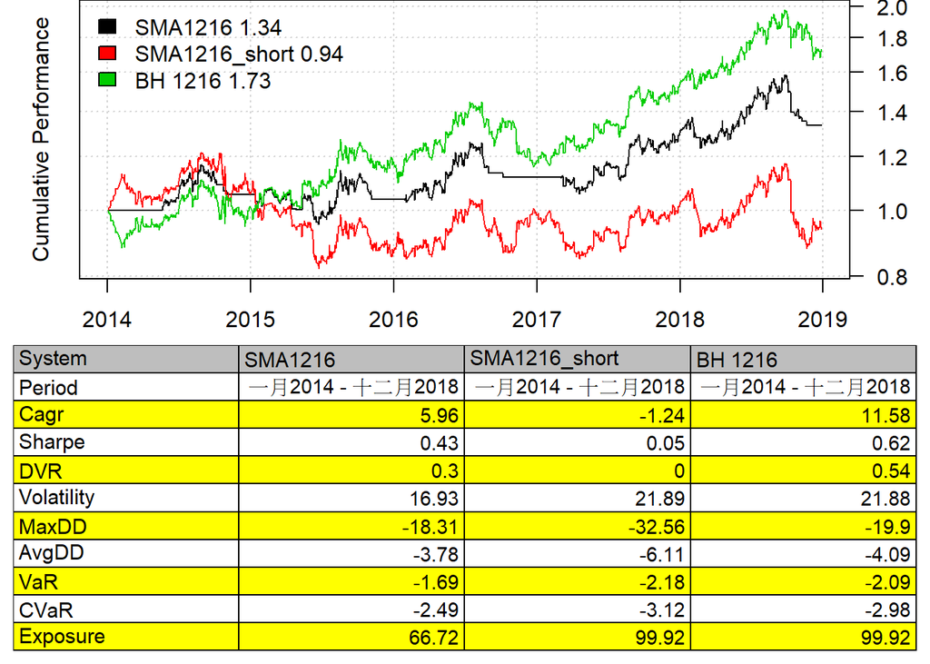

```r
strategy.performance.snapshoot(models.1, T)
```

# 第三張圖：

顯示出Sharpe、DVR、Cagr、MaxDD四個的長條圖。

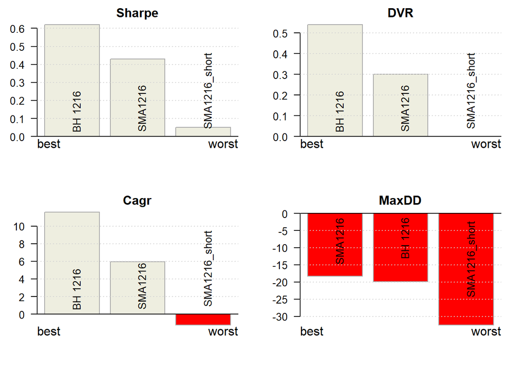

```r
strategy.performance.snapshoot(models.1, control=list(comparison=T), sort.performance=T)
```

# 第四張圖：

顯示為表格。

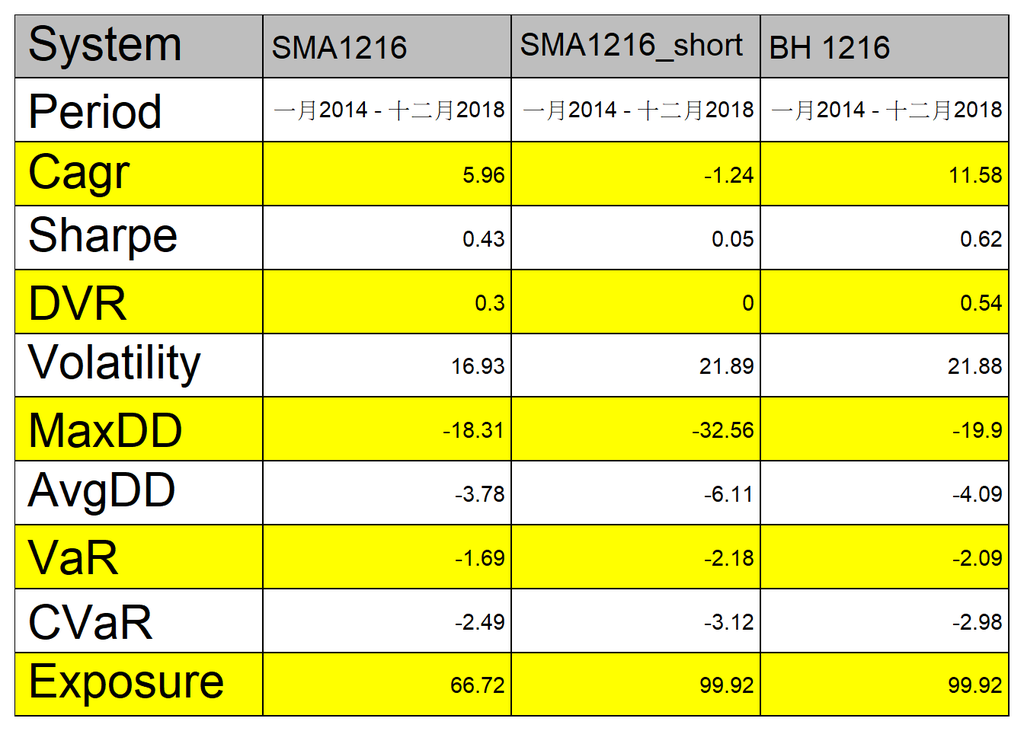

```
##            SMA1216                 SMA1216_short
## Period     "一月2014 - 十二月2018" "一月2014 - 十二月2018"
## Cagr       "5.96"                  "-1.24"
## Sharpe     "0.43"                  "0.05"
## DVR        "0.3"                   "0"
## Volatility "16.93"                 "21.89"
## MaxDD      "-18.31"                "-32.56"
## AvgDD      "-3.78"                 "-6.11"
## VaR        "-1.69"                 "-2.18"
## CVaR       "-2.49"                 "-3.12"
## Exposure   "66.72"                 "99.92"
##            BH 1216
## Period     "一月2014 - 十二月2018"
## Cagr       "11.58"
## Sharpe     "0.62"
## DVR        "0.54"
## Volatility "21.88"
## MaxDD      "-19.9"
## AvgDD      "-4.09"
## VaR        "-2.09"
## CVaR       "-2.98"
## Exposure   "99.92"
```

```r
plotbt.strategy.sidebyside(models.1, return.table=T)
```

```r
library(ggplot2)
all.1216<-merge.xts(sma90.1216$equity,
                    sma90.1216.short$equity,
                    buy.hold.1216$equity)
colnames(all.1216)<-c("sma1216", "sma1216 short", "BH")
head(all.1216)
```

```
##            sma1216 sma1216 short        BH
## 2014-01-02       1      1.000000 1.0000000
## 2014-01-03       1      1.009156 0.9908439
## 2014-01-06       1      1.009156 0.9908439
## 2014-01-07       1      1.011172 0.9888641
## 2014-01-08       1      1.014968 0.9851522
## 2014-01-09       1      1.032050 0.9685721
```

```r
all.1216.long<-fortify(all.1216, melt=T)
head(all.1216.long)
```

```
##        Index  Series Value
## 1 2014-01-02 sma1216     1
## 2 2014-01-03 sma1216     1
## 3 2014-01-06 sma1216     1
## 4 2014-01-07 sma1216     1
## 5 2014-01-08 sma1216     1
## 6 2014-01-09 sma1216     1
```

圖的標題為Cumulative returns of 1216s。

X軸為year，Y軸為cumulative returns。

粉紅色線為sma1216，綠色線為sma1216 short，藍色線為BH。

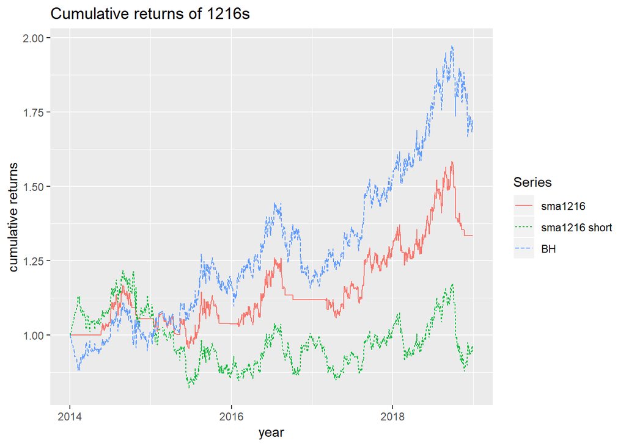

```r
title = "Cumulative returns of 1216s"
p1 = ggplot(all.1216.long, aes(x = Index, y = Value)) +
  geom_line(aes(linetype = Series, color = Series)) +
  #geom_point(aes(shape = Series))+
  xlab("year") + ylab("cumulative returns")+
  ggtitle(title)
p1
```

## 1301

讀取1301的資料。

```r
library(xts)
data1<-new.env()
data1$prices<-tw20.all.1$'1301'
prices<-data1$prices
sma1301<-SMA(prices, 90)
head(sma1301, 91)
```

```
##                 SMA
## 2014-01-02       NA
## 2014-01-03       NA
## 2014-01-06       NA
## 2014-01-07       NA
## 2014-01-08       NA
## 2014-01-09       NA
## 2014-01-10       NA
## 2014-01-13       NA
## 2014-01-14       NA
## 2014-01-15       NA
## 2014-01-16       NA
## 2014-01-17       NA
## 2014-01-20       NA
## 2014-01-21       NA
## 2014-01-22       NA
## 2014-01-23       NA
## 2014-01-24       NA
## 2014-01-27       NA
## 2014-02-05       NA
## 2014-02-06       NA
## 2014-02-07       NA
## 2014-02-10       NA
## 2014-02-11       NA
## 2014-02-12       NA
## 2014-02-13       NA
## 2014-02-14       NA
## 2014-02-17       NA
## 2014-02-18       NA
## 2014-02-19       NA
## 2014-02-20       NA
## 2014-02-21       NA
## 2014-02-24       NA
## 2014-02-25       NA
## 2014-02-26       NA
## 2014-02-27       NA
## 2014-03-03       NA
## 2014-03-04       NA
## 2014-03-05       NA
## 2014-03-06       NA
```

[output cut: 37 more lines]

```
## 2014-04-30       NA
## 2014-05-02       NA
## 2014-05-05       NA
## 2014-05-06       NA
## 2014-05-07       NA
## 2014-05-08       NA
## 2014-05-09       NA
## 2014-05-12       NA
## 2014-05-13       NA
## 2014-05-14       NA
## 2014-05-15       NA
## 2014-05-16       NA
## 2014-05-19       NA
## 2014-05-20 63.12522
## 2014-05-21 63.09878
```

分別看日期、價錢。

```r
bt.prep(data1, align='keep.all')
names(data1)
```

```
## [1] "prices"          "dates"           "weight"          "symbolnames"
## [5] "execution.price"
```

```r
data1$dates
```

```
##    [1] "2014-01-02" "2014-01-03" "2014-01-06" "2014-01-07" "2014-01-08"
##    [6] "2014-01-09" "2014-01-10" "2014-01-13" "2014-01-14" "2014-01-15"
##   [11] "2014-01-16" "2014-01-17" "2014-01-20" "2014-01-21" "2014-01-22"
##   [16] "2014-01-23" "2014-01-24" "2014-01-27" "2014-02-05" "2014-02-06"
##   [21] "2014-02-07" "2014-02-10" "2014-02-11" "2014-02-12" "2014-02-13"
##   [26] "2014-02-14" "2014-02-17" "2014-02-18" "2014-02-19" "2014-02-20"
##   [31] "2014-02-21" "2014-02-24" "2014-02-25" "2014-02-26" "2014-02-27"
##   [36] "2014-03-03" "2014-03-04" "2014-03-05" "2014-03-06" "2014-03-07"
##   [41] "2014-03-10" "2014-03-11" "2014-03-12" "2014-03-13" "2014-03-14"
##   [46] "2014-03-17" "2014-03-18" "2014-03-19" "2014-03-20" "2014-03-21"
##   [51] "2014-03-24" "2014-03-25" "2014-03-26" "2014-03-27" "2014-03-28"
##   [56] "2014-03-31" "2014-04-01" "2014-04-02" "2014-04-03" "2014-04-07"
##   [61] "2014-04-08" "2014-04-09" "2014-04-10" "2014-04-11" "2014-04-14"
##   [66] "2014-04-15" "2014-04-16" "2014-04-17" "2014-04-18" "2014-04-21"
##   [71] "2014-04-22" "2014-04-23" "2014-04-24" "2014-04-25" "2014-04-28"
```

[output cut: 231 more lines]

```r
data1$prices
```

```
##            prices
## 2014-01-02     NA
## 2014-01-03     NA
## 2014-01-06     NA
## 2014-01-07     NA
## 2014-01-08     NA
## 2014-01-09     NA
## 2014-01-10     NA
## 2014-01-13     NA
## 2014-01-14     NA
## 2014-01-15     NA
## 2014-01-16     NA
## 2014-01-17     NA
## 2014-01-20     NA
## 2014-01-21     NA
## 2014-01-22     NA
## 2014-01-23     NA
## 2014-01-24     NA
## 2014-01-27     NA
## 2014-02-05     NA
## 2014-02-06     NA
## 2014-02-07     NA
## 2014-02-10     NA
## 2014-02-11     NA
## 2014-02-12     NA
## 2014-02-13     NA
## 2014-02-14     NA
## 2014-02-17     NA
## 2014-02-18     NA
## 2014-02-19     NA
## 2014-02-20     NA
## 2014-02-21     NA
## 2014-02-24     NA
## 2014-02-25     NA
## 2014-02-26     NA
## 2014-02-27     NA
## 2014-03-03     NA
## 2014-03-04     NA
## 2014-03-05     NA
## 2014-03-06     NA
```

[output cut: 1175 more lines]

```
## 2018-12-11     NA
## 2018-12-12     NA
## 2018-12-13     NA
## 2018-12-14     NA
## 2018-12-17     NA
## 2018-12-18     NA
## 2018-12-19     NA
## 2018-12-20     NA
## 2018-12-21     NA
## 2018-12-22     NA
## 2018-12-24     NA
## 2018-12-25     NA
## 2018-12-26     NA
## 2018-12-27     NA
## 2018-12-28     NA
```

```r
data1$prices<-prices

class(data1$dates)
```

```
## [1] "Date"
```

```r
data1$execution.price = prices
data1$weight[] = 1
buy.hold.1301 <- bt.run.share(data1, clean.signal=F, trade.summary = TRUE)
```

```
## Latest weights :
##            prices
## 2018-12-28    100
##
## Performance summary :
##  CAGR    Best    Worst
##  9.1 5.4 -9.3
```

```r
buy.hold.1301 <-bt.run(data1)
```

```
## Latest weights :
##            prices
## 2018-12-28    100
##
## Performance summary :
##  CAGR    Best    Worst
##  9.1 5.4 -9.3
```

讀取sma 90天的資料。

```r
sma1301<-SMA(prices, 90)
head(sma1301, 91)
```

```
##                 SMA
## 2014-01-02       NA
## 2014-01-03       NA
## 2014-01-06       NA
## 2014-01-07       NA
## 2014-01-08       NA
## 2014-01-09       NA
## 2014-01-10       NA
## 2014-01-13       NA
## 2014-01-14       NA
## 2014-01-15       NA
## 2014-01-16       NA
## 2014-01-17       NA
## 2014-01-20       NA
## 2014-01-21       NA
## 2014-01-22       NA
## 2014-01-23       NA
## 2014-01-24       NA
## 2014-01-27       NA
## 2014-02-05       NA
## 2014-02-06       NA
## 2014-02-07       NA
## 2014-02-10       NA
## 2014-02-11       NA
## 2014-02-12       NA
## 2014-02-13       NA
## 2014-02-14       NA
## 2014-02-17       NA
## 2014-02-18       NA
## 2014-02-19       NA
## 2014-02-20       NA
## 2014-02-21       NA
## 2014-02-24       NA
## 2014-02-25       NA
## 2014-02-26       NA
## 2014-02-27       NA
## 2014-03-03       NA
## 2014-03-04       NA
## 2014-03-05       NA
## 2014-03-06       NA
```

[output cut: 37 more lines]

```
## 2014-04-30       NA
## 2014-05-02       NA
## 2014-05-05       NA
## 2014-05-06       NA
## 2014-05-07       NA
## 2014-05-08       NA
## 2014-05-09       NA
## 2014-05-12       NA
## 2014-05-13       NA
## 2014-05-14       NA
## 2014-05-15       NA
## 2014-05-16       NA
## 2014-05-19       NA
## 2014-05-20 63.12522
## 2014-05-21 63.09878
```

```r
data1$weight[] <- iif(prices >= sma1301, 1, 0)
sma90.1301 <- bt.run(data1, trade.summary=T)
```

```
## Latest weights :
##            prices
## 2018-12-28      0
##
## Performance summary :
##  CAGR    Best    Worst
##  4.1 4.8 -9.3
```

```r
data1$weight[] <- iif(prices >= sma1301, 1, -1)
sma90.1301.short <- bt.run(data1, trade.summary=T)
```

```
## Latest weights :
##            prices
## 2018-12-28   -100
##
## Performance summary :
##  CAGR    Best    Worst
##  -2  6   -9.3
```

```r
models.2<-list("SMA1301"= sma90.1301,
             "SMA1301_short" = sma90.1301.short,
             "BH 1301" = buy.hold.1301)
```

# 第一、二張圖：

黑色線為SMA1301 1.22，紅色線為SMA1301_short 0.90，綠色線為BH 1301 1.54。並顯示出表格。

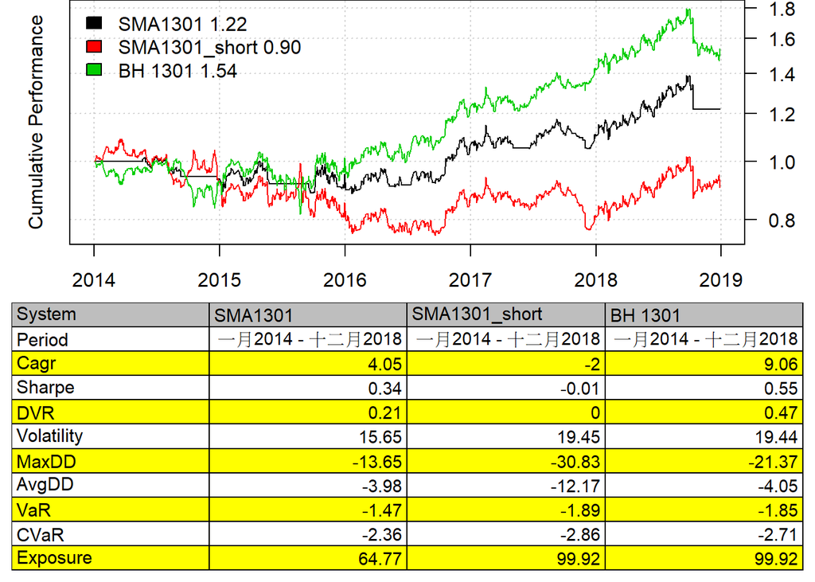

```r
strategy.performance.snapshoot(models.2, T)
```

# 第三張圖：

顯示出Sharpe、DVR、Cagr、MaxDD四個的長條圖。

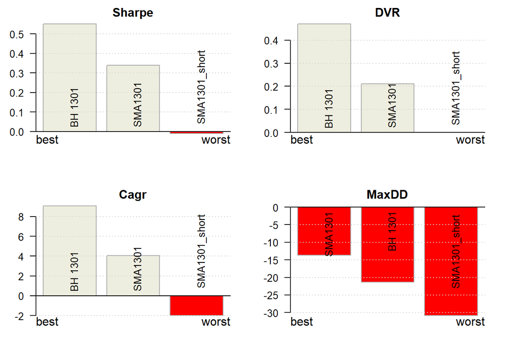

```r
strategy.performance.snapshoot(models.2, control=list(comparison=T), sort.performance=T)
```

# 第四張圖：

顯示為表格。

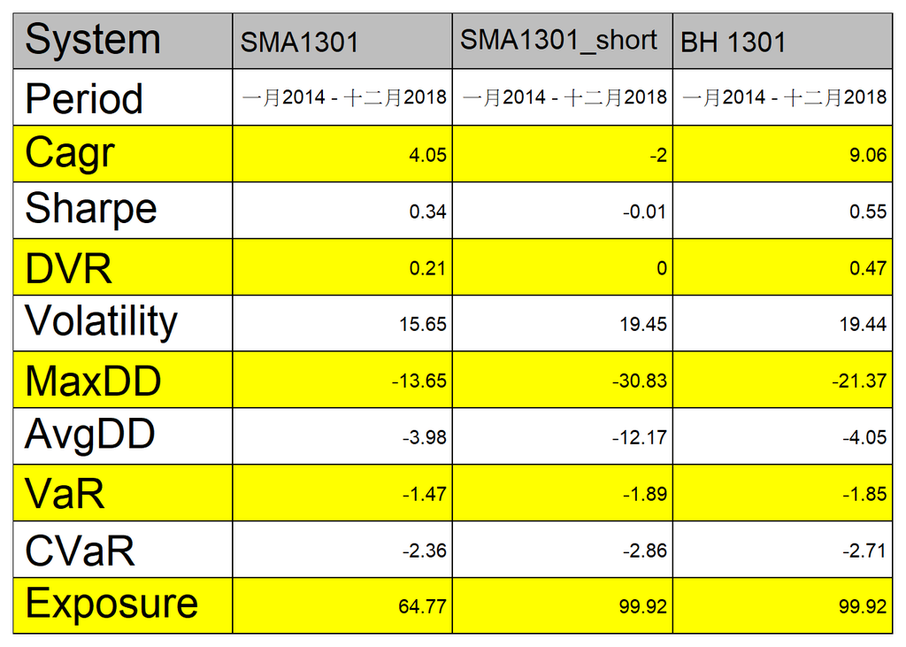

```
##            SMA1301                 SMA1301_short
## Period     "一月2014 - 十二月2018" "一月2014 - 十二月2018"
## Cagr       "4.05"                  "-2"
## Sharpe     "0.34"                  "-0.01"
## DVR        "0.21"                  "0"
## Volatility "15.65"                 "19.45"
## MaxDD      "-13.65"                "-30.83"
## AvgDD      "-3.98"                 "-12.17"
## VaR        "-1.47"                 "-1.89"
## CVaR       "-2.36"                 "-2.86"
## Exposure   "64.77"                 "99.92"
##            BH 1301
## Period     "一月2014 - 十二月2018"
## Cagr       "9.06"
## Sharpe     "0.55"
## DVR        "0.47"
## Volatility "19.44"
## MaxDD      "-21.37"
## AvgDD      "-4.05"
## VaR        "-1.85"
## CVaR       "-2.71"
## Exposure   "99.92"
```

```r
plotbt.strategy.sidebyside(models.2, return.table=T)
```

```r
library(ggplot2)
all.1301<-merge.xts(sma90.1301$equity,
                    sma90.1301.short$equity,
                    buy.hold.1301$equity)
colnames(all.1301)<-c("sma1301", "sma1301 short", "BH")
head(all.1301)
```

```
##            sma1301 sma1301 short        BH
## 2014-01-02       1      1.000000 1.0000000
## 2014-01-03       1      1.003815 0.9961850
## 2014-01-06       1      1.010120 0.9899283
## 2014-01-07       1      1.017750 0.9824508
## 2014-01-08       1      1.022966 0.9774149
## 2014-01-09       1      1.012425 0.9874866
```

```r
all.1301.long<-fortify(all.1301, melt=T)
head(all.1301.long)
```

```
##        Index  Series Value
## 1 2014-01-02 sma1301     1
## 2 2014-01-03 sma1301     1
## 3 2014-01-06 sma1301     1
## 4 2014-01-07 sma1301     1
## 5 2014-01-08 sma1301     1
## 6 2014-01-09 sma1301     1
```

圖的標題為Cumulative returns of 1301s。

X軸為year，Y軸為cumulative returns。

粉紅色線為sma1301，綠色線為sma1301 short，藍色線為BH。

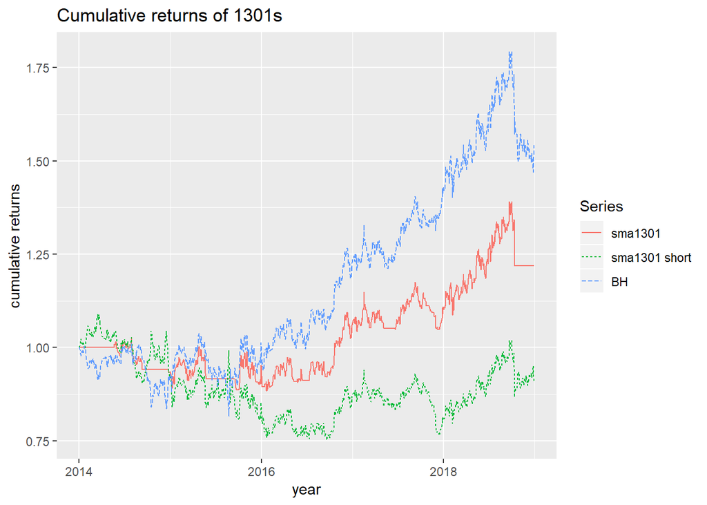

```r
title = "Cumulative returns of 1301s"
p2 = ggplot(all.1301.long, aes(x = Index, y = Value)) +
  geom_line(aes(linetype = Series, color = Series)) +
  #geom_point(aes(shape = Series))+
  xlab("year") + ylab("cumulative returns")+
  ggtitle(title)
p2
```